# QAQC.Comparisons

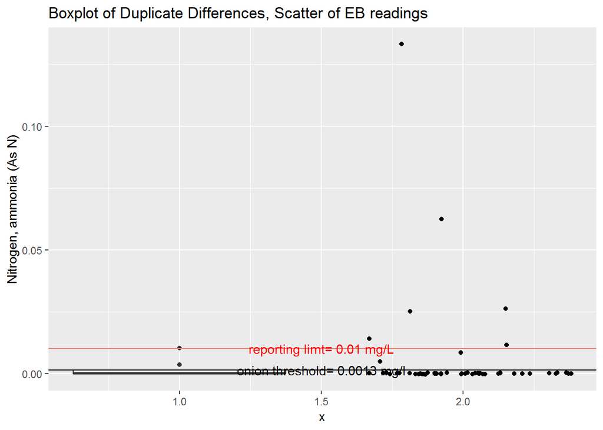

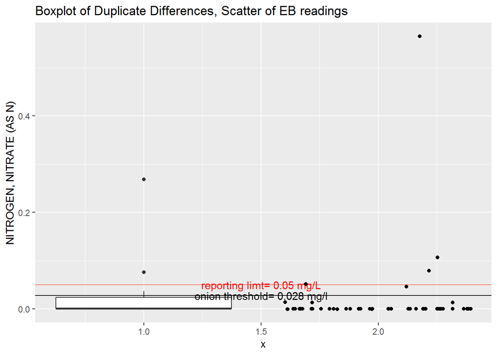

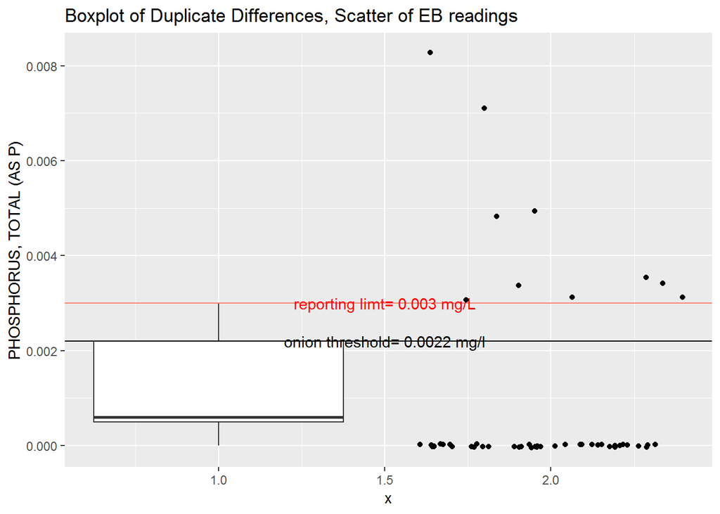

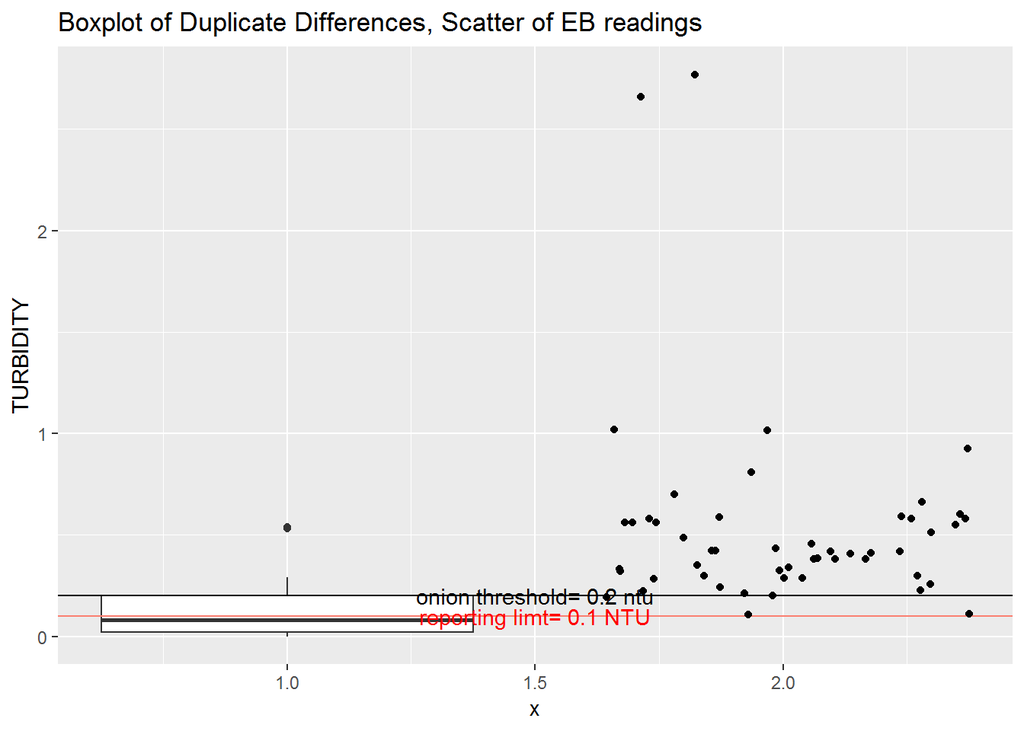

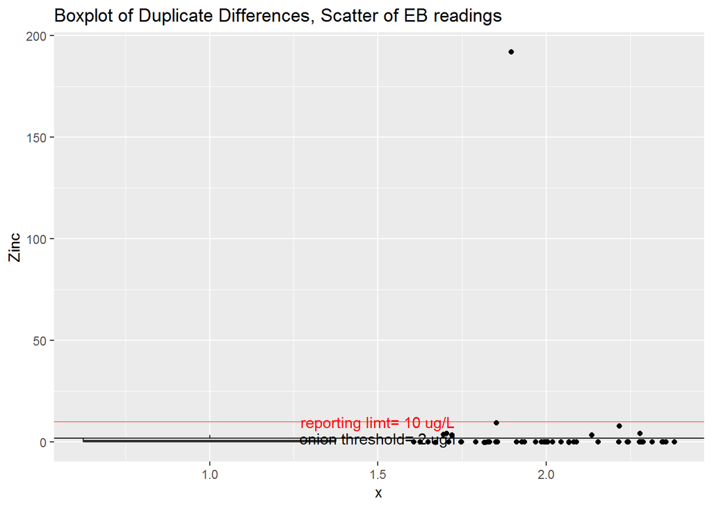

Replotting parameters with outliers

I’m replotting these parameters to remove extreme outliers so we can better see the distribution around the limits

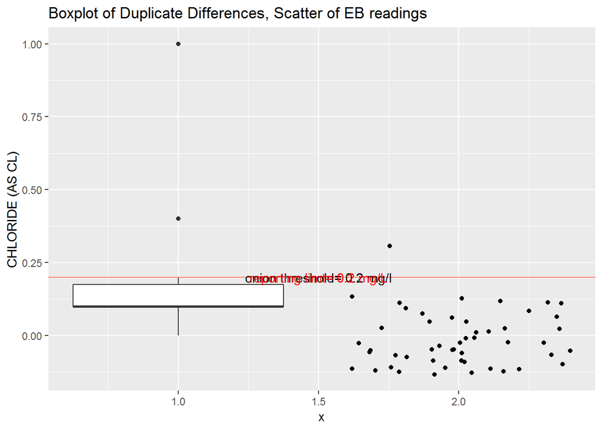

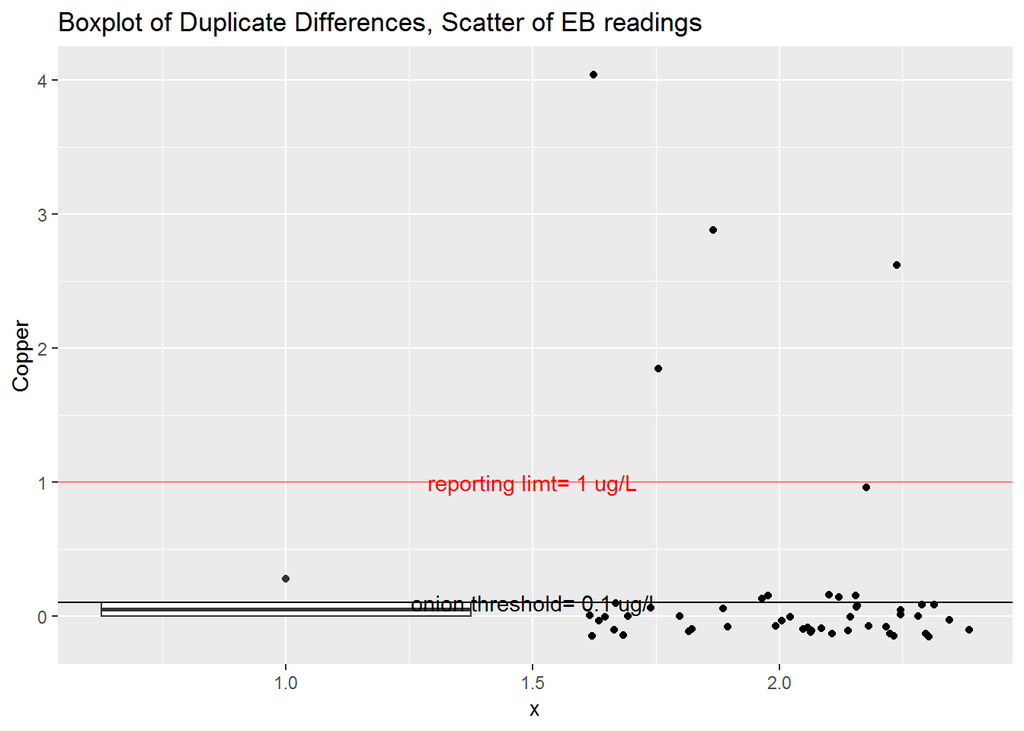

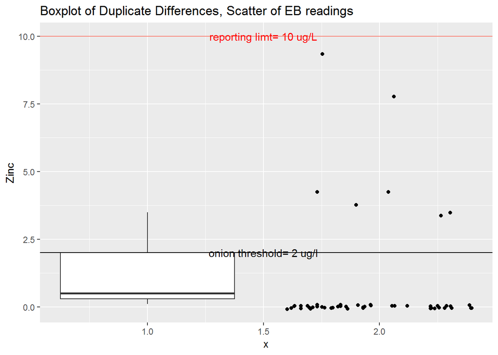

## Precision Assessment

Precision fail: duplicate samples differ by more than the precision criteria  
The QAPP requires that we analyze duplicates for nutrients, solids, turbidity, conductivity, hardness, metals, and minerals (see section II.5.A.a). This is everything excluding in situ parameters, alkalinity, DOC, and chlorophyll a  
If the sample is a non detect, the duplicate is spiked and compared to the spike sample. For this reason we need to make sure the duplicate and spike bottles are collected separately.

Routine sampling only collected 4 duplicates so Gavin didn’t both analyzing these

Again from the Ohio EPA (https://www.epa.ohio.gov/portals/35/documents/sw_samplingmanual.pdf):  
“This leaves us with a two-tiered system for duplicates. If our %RPD is below the values from our equation (i.e., below the curve), we accept both data points as valid. If the %RPD exceeds the %RPD from the equation, we don’t know which value to believe is correct, the sample or the duplicate value, so we must reject (“R” qualify) both data points. At that point, particularly if multiple duplicate pairs have been rejected, the sampler(s) should look into possible causes for the disagreement and work to minimize those causes for future sampling.”

### Failures per project

| project | Blank | FAIL | PASS | percFAIL |
| --- | --- | --- | --- | --- |
| Screening | 460 | 26 | 158 | 4.0 |
| Wallkill | 269 | 10 | 43 | 3.1 |

### Failures per parameter

|  | chemical_name | Blank | FAIL | PASS | percFail |
| --- | --- | --- | --- | --- | --- |
| 8 | Conductivity at 25 Degrees Celsius | 0 | 12 | 5 | 71.0 |
| 19 | PH | 0 | 12 | 5 | 71.0 |
| 7 | Chlorophyll A | 0 | 1 | 2 | 33.0 |
| 16 | Nitrogen, ammonia (As N) | 8 | 4 | 5 | 24.0 |
| 17 | NITROGEN, NITRATE (AS N) | 1 | 3 | 13 | 18.0 |
| 24 | TURBIDITY | 0 | 3 | 14 | 18.0 |
| 20 | PHOSPHORUS, TOTAL (AS P) | 0 | 1 | 16 | 5.9 |
| 1 |  | 572 | 0 | 0 | 0.0 |
| 2 | ALKALINITY, TOTAL (AS CaCO3) | 2 | 0 | 15 | 0.0 |
| 3 | Aluminum | 0 | 0 | 17 | 0.0 |
| 4 | Arsenic | 14 | 0 | 3 | 0.0 |
| 5 | Cadmium | 17 | 0 | 0 | 0.0 |
| 6 | CHLORIDE (AS CL) | 3 | 0 | 14 | 0.0 |
| 9 | Copper | 9 | 0 | 8 | 0.0 |
| 10 | HARDNESS (AS CACO3) | 4 | 0 | 13 | 0.0 |
| 11 | Iron | 2 | 0 | 15 | 0.0 |
| 12 | Lead | 13 | 0 | 4 | 0.0 |
| 13 | Magnesium | 1 | 0 | 16 | 0.0 |
| 14 | Nickel | 4 | 0 | 13 | 0.0 |
| 15 | Nitrate+Nitrite as Nitrogen | 17 | 0 | 0 | 0.0 |
| 18 | NITROGEN, NITRITE | 17 | 0 | 0 | 0.0 |
| 21 | Silver | 17 | 0 | 0 | 0.0 |
| 22 | Temperature of pH Analysis | 0 | 0 | 17 | 0.0 |
| 23 | TOTAL DISSOLVED SOLIDS (RESIDUE, FILTERABLE) | 0 | 0 | 3 | 0.0 |
| 25 | Zinc | 14 | 0 | 3 | 0.0 |
| 26 | Calcium | 14 | 0 | 0 | 0.0 |

### Failures: parameter by project

|  | parameter | project | FAIL | PASS | Blank | percFail |
| --- | --- | --- | --- | --- | --- | --- |
| 1 |  | Screening | 0 | 0 | 322 | 0 |
| 2 |  | Wallkill | 0 | 0 | 250 | 0 |
| 3 | ALKALINITY, TOTAL (AS CaCO3) | Screening | 0 | 12 | 2 | 0 |
| 4 | ALKALINITY, TOTAL (AS CaCO3) | Wallkill | 0 | 3 | 0 | 0 |
| 5 | Aluminum | Screening | 0 | 14 | 0 | 0 |
| 6 | Aluminum | Wallkill | 0 | 3 | 0 | 0 |
| 7 | Arsenic | Screening | 0 | 2 | 12 | 0 |
| 8 | Arsenic | Wallkill | 0 | 1 | 2 | 0 |
| 9 | Cadmium | Screening | 0 | 0 | 14 | 0 |
| 10 | Cadmium | Wallkill | 0 | 0 | 3 | 0 |

[output cut: 39 more lines]

### Sortable Table

|  | project | chemical_name | sample_date | sample_name | DUP_test |
| --- | --- | --- | --- | --- | --- |
| 1 | Screening |  |  |  |  |
| 323 | Wallkill |  |  |  |  |
| 573 | Wallkill | NITROGEN, NITRATE (AS N) | 9/20/2017 11:15 | 13-GUNK-0.4 DUP | PASS |
| 574 | Wallkill | Nitrogen, ammonia (As N) | 9/20/2017 11:15 | 13-GUNK-0.4 DUP | FAIL |
| 575 | Wallkill | Conductivity at 25 Degrees Celsius | 9/20/2017 11:15 | 13-GUNK-0.4 DUP | FAIL |
| 576 | Wallkill | TURBIDITY | 9/20/2017 11:15 | 13-GUNK-0.4 DUP | PASS |
| 577 | Wallkill | Iron | 9/20/2017 11:15 | 13-GUNK-0.4 DUP | PASS |
| 578 | Wallkill | Magnesium | 9/20/2017 11:15 | 13-GUNK-0.4 DUP | PASS |
| 579 | Wallkill | Aluminum | 9/20/2017 11:15 | 13-GUNK-0.4 DUP | PASS |
| 580 | Wallkill | Lead | 9/20/2017 11:15 | 13-GUNK-0.4 DUP |  |

[output cut: 386 more lines]

## Accuracy Assessment

Accuracy fail: designated ‘spike’ samples are spiked with a known concentration. The difference between the concentration before and after should be the spiked amount +/- the accuracy criteria set forth in table 3 (screening) and table 4 (routine)

Also check that the lab has met their own lab accuracy criteria which is in the case narrative of the data package.

%%%!!!%%% I had to replace all the blank cells with NA in ‘qc_spike_status’ and ‘qc_dup_spike_status’ to make this work %%%!!!%%%

### Failures per project

|  | project | fail | pass | percFail |
| --- | --- | --- | --- | --- |
| 1 | 2018 | 61 | 544 | 10.0 |
| 4 | wallkill | 8 | 89 | 8.2 |
| 2 | routine | 14 | 390 | 3.5 |
| 3 | screening | 10 | 339 | 2.9 |

### Failures per parameter

|  | chemical_name | fail | pass | percFail |
| --- | --- | --- | --- | --- |
| 4 | Calcium | 30 | 39 | 43.0 |
| 1 | Aluminum | 17 | 65 | 21.0 |
| 24 | Sodium | 3 | 18 | 14.0 |
| 25 | SULFATE (AS SO4) | 3 | 18 | 14.0 |
| 21 | PHOSPHORUS, TOTAL (AS P) | 10 | 65 | 13.0 |
| 16 | Nitrate+Nitrite as Nitrogen | 8 | 72 | 10.0 |
| 20 | Orthophosphate as Phosphorus, Dissolved | 3 | 31 | 8.8 |
| 6 | CHLORIDE (AS CL) | 7 | 76 | 8.4 |
| 18 | NITROGEN, KJELDAHL, TOTAL | 4 | 53 | 7.0 |
| 12 | Magnesium | 4 | 69 | 5.5 |
| 26 | Zinc | 2 | 80 | 2.4 |
| 19 | NITROGEN, NITRITE | 2 | 84 | 2.3 |
| 2 | Arsenic | 0 | 76 | 0.0 |
| 3 | Cadmium | 0 | 82 | 0.0 |
| 5 | Carbon, Dissolved Organic (DOC) | 0 | 17 | 0.0 |
| 7 | Copper | 0 | 82 | 0.0 |
| 8 | Fluoride, undistilled | 0 | 10 | 0.0 |
| 9 | HARDNESS (AS CACO3) | 0 | 9 | 0.0 |
| 10 | Iron | 0 | 73 | 0.0 |
| 11 | Lead | 0 | 82 | 0.0 |
| 13 | Manganese | 0 | 21 | 0.0 |
| 14 | Mercury | 0 | 15 | 0.0 |
| 15 | Nickel | 0 | 82 | 0.0 |
| 17 | Nitrogen, ammonia (As N) | 0 | 45 | 0.0 |
| 22 | Potassium | 0 | 21 | 0.0 |
| 23 | Silver | 0 | 76 | 0.0 |
| 27 | TOTAL ORGANIC CARBON | 0 | 1 | 0.0 |

### Failures: parameter by project

|  | parameter | project | pass | fail | percFail |
| --- | --- | --- | --- | --- | --- |
| 1 | Aluminum | 2018 | 25 | 12 | 32 |
| 2 | Aluminum | routine | 20 | 0 | 0 |
| 3 | Aluminum | screening | 16 | 3 | 16 |
| 4 | Aluminum | wallkill | 4 | 2 | 33 |
| 5 | Arsenic | 2018 | 36 | 0 | 0 |
| 6 | Arsenic | routine | 14 | 0 | 0 |
| 7 | Arsenic | screening | 20 | 0 | 0 |
| 8 | Arsenic | wallkill | 6 | 0 | 0 |
| 9 | Cadmium | 2018 | 37 | 0 | 0 |
| 10 | Cadmium | routine | 19 | 0 | 0 |

[output cut: 72 more lines]

### Sortable Table

|  | project | chemical_name | sample_date | sample_name | pass | qc_spike_recovery |
| --- | --- | --- | --- | --- | --- | --- |
| 35 | routine | Nitrogen, ammonia (As N) | 8/14/2017 3:00 | 01BUFF-1.7 EB_08142017_WS | pass | 98 |
| 72 | routine | Mercury | 6/14/2017 13:00 | 01BUFF-1.7_06142017_WSS | pass | 91 |
| 73 | routine | Iron | 6/14/2017 13:00 | 01BUFF-1.7_06142017_WS | pass | 96 |
| 74 | routine | Magnesium | 6/14/2017 13:00 | 01BUFF-1.7_06142017_WS | pass | 92 |
| 75 | routine | Manganese | 6/14/2017 13:00 | 01BUFF-1.7_06142017_WS | pass | 101 |
| 76 | routine | Sodium | 6/14/2017 13:00 | 01BUFF-1.7_06142017_WS | pass | 95 |
| 77 | routine | Calcium | 6/14/2017 13:00 | 01BUFF-1.7_06142017_WS | pass | 95 |
| 78 | routine | Potassium | 6/14/2017 13:00 | 01BUFF-1.7_06142017_WS | pass | 98 |
| 79 | routine | Lead | 6/14/2017 13:00 | 01BUFF-1.7_06142017_WS | pass | 104 |
| 80 | routine | Nickel | 6/14/2017 13:00 | 01BUFF-1.7_06142017_WS | pass | 104 |

[output cut: 1445 more lines]